# HW3 - Text Mining and Sentiment Analysis

Author

Chi-Erh Chiu

## Set up

```r
# install.packages("tidytext")
# install.packages("textdata")
```

```r
library(tidyverse)
library(tidytext)
library(ggplot2)
library(textdata)
```

## Text Mining

### Load Data

```r
pubmed <- read_csv("pubmed.csv")
glimpse(pubmed)
```

```
Rows: 3,241
Columns: 2
$ abstract <chr> "Background and aims: Many patients with coronavirus disease …
$ term     <chr> "covid", "covid", "covid", "covid", "covid", "covid", "covid"…
```

### Question 1

```r
# Count abstracts per search term
abstracts_per_term <- pubmed %>%
  count(term, name = "n_abstracts") %>%
  arrange(desc(n_abstracts))

print("Number of abstracts associated with each search term:")
```

```
[1] "Number of abstracts associated with each search term:"
```

```r
print(abstracts_per_term)
```

```
# A tibble: 5 × 2
  term            n_abstracts
  <chr>                 <int>
1 covid                   981
2 prostate cancer         787
3 preeclampsia            780
4 cystic fibrosis         376
5 meningitis              317
```

```r
# Tokenize the abstracts
tokens <- pubmed %>%
  unnest_tokens(word, abstract)

# Count the number of each token
token_counts <- tokens %>%
  count(word, sort = TRUE)

print("Top 20 most common tokens overall:")
```

```
[1] "Top 20 most common tokens overall:"
```

```r
print(head(token_counts, 20))
```

```
# A tibble: 20 × 2
   word         n
   <chr>    <int>
 1 the      28126
 2 of       24760
 3 and      19993
 4 in       14653
 5 to       10920
 6 a         8245
 7 with      8038
 8 covid     7275
 9 19        7080
10 is        5649
11 for       5492
12 patients  4674
13 cancer    3999
14 prostate  3832
15 was       3315
16 that      3226
17 were      3226
18 as        3159
19 this      3158
20 are       2833
```

```r
# Find the 5 most common tokens for each search term
top5_by_term <- tokens %>%
  count(term, word, sort = TRUE) %>%
  group_by(term) %>%
  slice_max(n, n = 5) %>%
  ungroup()

print("5 most common tokens for each search term:")
```

```
[1] "5 most common tokens for each search term:"
```

```r
print(top5_by_term, n = Inf)
```

```
# A tibble: 25 × 3
   term            word         n
   <chr>           <chr>    <int>
 1 covid           the       9741
 2 covid           of        7668
 3 covid           covid     7275
 4 covid           19        7035
 5 covid           and       6861
 6 cystic fibrosis the       2677
 7 cystic fibrosis of        2304
 8 cystic fibrosis and       1777
 9 cystic fibrosis in        1497
10 cystic fibrosis to        1011
11 meningitis      the       2489
12 meningitis      of        2269
13 meningitis      and       1683
14 meningitis      in        1322
15 meningitis      a          830
16 preeclampsia    the       7119
17 preeclampsia    of        6837
18 preeclampsia    and       5255
19 preeclampsia    in        3869
20 preeclampsia    to        2651
21 prostate cancer the       6100
22 prostate cancer of        5682
23 prostate cancer and       4417
24 prostate cancer cancer    3840
25 prostate cancer prostate  3832
```

There are 3241 abstracts in total across the five search terms. The counts show that “covid” has the largest number of abstracts (981), followed by “prostate cancer” (787), “preeclampsia” (780), “cystic fibrosis” (376), and “meningitis” (317). The most common tokens are mostly stop words (common words like “the”, “of”, “and”, “in”, “to”) which don’t provide much meaningful information. These words appear frequently across all search terms but they don’t tell us much about the specific topics.

### Question 2

```r
# Remove stop words
tokens_no_stop <- tokens %>%
  anti_join(stop_words, by = "word")

# Count tokens after removing stop words
token_counts_no_stop <- tokens_no_stop %>%
  count(word, sort = TRUE)

print("Top 20 most common tokens after removing stop words:")
```

```
[1] "Top 20 most common tokens after removing stop words:"
```

```r
print(head(token_counts_no_stop, 20))
```

```
# A tibble: 20 × 2
   word             n
   <chr>        <int>
 1 covid         7275
 2 19            7080
 3 patients      4674
 4 cancer        3999
 5 prostate      3832
 6 disease       2574
 7 pre           2165
 8 eclampsia     2005
 9 preeclampsia  1863
10 treatment     1841
11 clinical      1682
12 risk          1588
13 women         1327
14 study         1299
15 results       1281
16 severe        1063
17 diagnosis     1015
18 pregnancy     1011
19 data           945
20 health         922
```

```r
# Find the 5 most common tokens for each search term after removing stop words
top5_by_term_no_stop <- tokens_no_stop %>%
  count(term, word, sort = TRUE) %>%
  group_by(term) %>%
  slice_max(n, n = 5) %>%
  ungroup()

print("5 most common tokens for each search term (without stop words):")
```

```
[1] "5 most common tokens for each search term (without stop words):"
```

```r
print(top5_by_term_no_stop, n = Inf)
```

```
# A tibble: 25 × 3
   term            word             n
   <chr>           <chr>        <int>
 1 covid           covid         7275
 2 covid           19            7035
 3 covid           patients      2293
 4 covid           disease        943
 5 covid           pandemic       800
 6 cystic fibrosis fibrosis       867
 7 cystic fibrosis cystic         862
 8 cystic fibrosis cf             625
 9 cystic fibrosis patients       586
10 cystic fibrosis disease        400
11 meningitis      patients       446
12 meningitis      meningitis     429
13 meningitis      meningeal      219
14 meningitis      csf            206
15 meningitis      clinical       187
16 preeclampsia    pre           2038
17 preeclampsia    eclampsia     2005
18 preeclampsia    preeclampsia  1863
19 preeclampsia    women         1196
20 preeclampsia    pregnancy      969
21 prostate cancer cancer        3840
22 prostate cancer prostate      3832
23 prostate cancer patients       934
24 prostate cancer treatment      926
25 prostate cancer disease        652
```

Yes, removing stop words significantly changes the most frequent tokens.

Now we see domain specific words related to each search term:

- For covid: “covid”, “19”, “patients”, “disease”, “pandemic”
- For cystic fibrosis: “fibrosis”, “cystic”, “cf”, “patients”, “disease”
- For meningitis: “patients”, “meningitis”, “meningeal”, “csf”, “clinical”
- For preeclampsia: “pre”, “eclampsia”, “preeclampsia”, “women”, “pregnancy”
- For prostate cancer: “cancer”, “prostate”, “patients”, “treatment”, “disease”

This confirms that removing stop words is essential to uncover meaningful biomedical vocabulary. The results now directly reflect the medical focus of each term, rather than grammatical filler.

### Question 3

```r
# Tokenize into bigrams
bigrams <- pubmed %>%
  unnest_tokens(bigram, abstract, token = "ngrams", n = 2)

# Count the most common bigrams
bigram_counts <- bigrams %>%
  count(bigram, sort = TRUE)

# Get top 10 bigrams
top10_bigrams <- bigram_counts %>%
  slice_max(n, n = 10)

print("Top 10 most common bigrams:")
```

```
[1] "Top 10 most common bigrams:"
```

```r
print(top10_bigrams)
```

```
# A tibble: 10 × 2
   bigram              n
   <chr>           <int>
 1 covid 19         6969
 2 of the           3883
 3 in the           3418
 4 prostate cancer  3222
 5 pre eclampsia    1854
 6 patients with    1587
 7 of covid         1519
 8 and the          1154
 9 to the           1061
10 of prostate       870
```

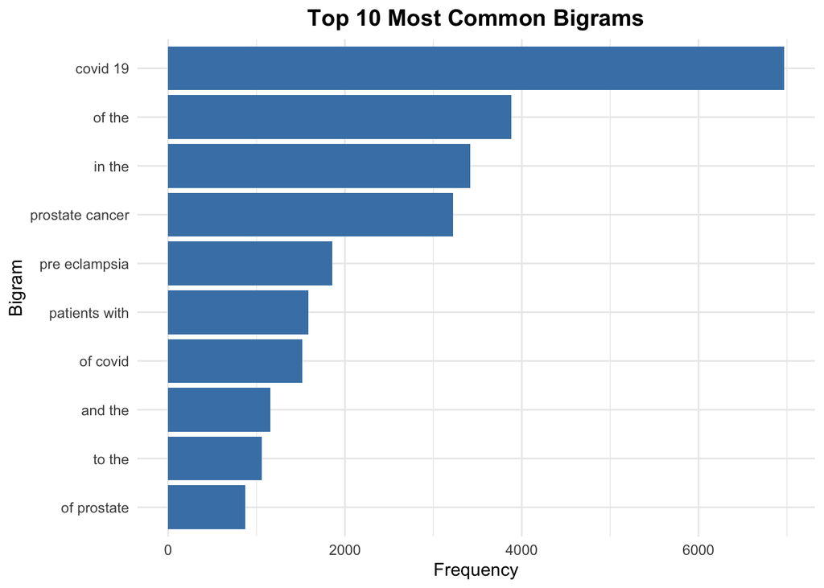

```r
# Visualize top 10 bigrams
ggplot(top10_bigrams, aes(x = reorder(bigram, n), y = n)) +
  geom_col(fill = "steelblue") +
  coord_flip() +
  labs(title = "Top 10 Most Common Bigrams",
       x = "Bigram",
       y = "Frequency") +
  theme_minimal() +
  theme(plot.title = element_text(hjust = 0.5, size = 14, face = "bold"))
```

The top 10 most common bigrams are “covid 19”, “of the”, “in the”, “prostate cancer”, “pre eclampsia”, “patients with”, “of covid”, “and the”, “to the”, “of prostate”. They are dominated by two main categories: the search terms themselves (e.g., “covid 19,” “prostate cancer,” “pre eclampsia”) and combinations involving common stop words (e.g., “of the,” “in the,” “patients with”). “Covid 19” is by far the most frequent bigram. However, the high frequency of stop-word pairs like “of the” and “in the” provides little insight into the unique content of the abstracts. This suggests that to find more meaningful contextual bigrams, it would be necessary to remove stop words first before tokenizing or to filter the bigram list to exclude pairs containing them.

### Question 4

```r
# Calculate TF-IDF for each word-search term combination
tfidf_data <- tokens_no_stop %>%
  count(term, word) %>%
  bind_tf_idf(word, term, n)

# Get the 5 tokens with highest TF-IDF for each search term
top5_tfidf <- tfidf_data %>%
  group_by(term) %>%
  slice_max(tf_idf, n = 5) %>%
  ungroup() %>%
  arrange(term, desc(tf_idf))

print("Top 5 tokens by TF-IDF for each search term:")
```

```
[1] "Top 5 tokens by TF-IDF for each search term:"
```

```r
print(top5_tfidf, n = Inf)
```

```
# A tibble: 25 × 6
   term            word                n      tf   idf  tf_idf
   <chr>           <chr>           <int>   <dbl> <dbl>   <dbl>
 1 covid           covid            7275 0.0647  1.61  0.104
 2 covid           pandemic          800 0.00711 1.61  0.0114
 3 covid           coronavirus       647 0.00575 1.61  0.00926
 4 covid           sars              372 0.00331 1.61  0.00532
 5 covid           cov               334 0.00297 1.61  0.00478
 6 cystic fibrosis cf                625 0.0234  0.916 0.0215
 7 cystic fibrosis fibrosis          867 0.0325  0.511 0.0166
 8 cystic fibrosis cystic            862 0.0323  0.511 0.0165
 9 cystic fibrosis cftr               86 0.00322 1.61  0.00518
10 cystic fibrosis sweat              83 0.00311 1.61  0.00500
11 meningitis      meningitis        429 0.0164  1.61  0.0264
12 meningitis      meningeal         219 0.00837 1.61  0.0135
13 meningitis      pachymeningitis   149 0.00569 1.61  0.00917
14 meningitis      csf               206 0.00787 0.916 0.00721
15 meningitis      meninges          106 0.00405 1.61  0.00652
16 preeclampsia    eclampsia        2005 0.0255  1.61  0.0411
17 preeclampsia    preeclampsia     1863 0.0237  1.61  0.0382
18 preeclampsia    pregnancy         969 0.0123  0.511 0.00630
19 preeclampsia    maternal          797 0.0101  0.511 0.00518
20 preeclampsia    gestational       191 0.00243 1.61  0.00391
21 prostate cancer prostate         3832 0.0563  1.61  0.0906
22 prostate cancer androgen          305 0.00448 1.61  0.00721
23 prostate cancer psa               282 0.00414 1.61  0.00667
24 prostate cancer prostatectomy     215 0.00316 1.61  0.00508
25 prostate cancer castration        148 0.00217 1.61  0.00350
```

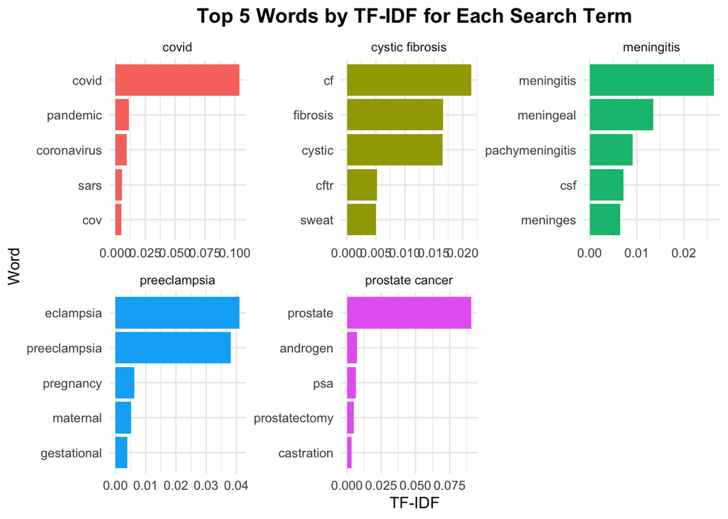

```r
# Visualize TF-IDF
top5_tfidf %>%
  mutate(word = reorder_within(word, tf_idf, term)) %>%
  ggplot(aes(x = word, y = tf_idf, fill = term)) +
  geom_col(show.legend = FALSE) +
  facet_wrap(~term, scales = "free") +
  coord_flip() +
  scale_x_reordered() +
  labs(title = "Top 5 Words by TF-IDF for Each Search Term",
       x = "Word",
       y = "TF-IDF") +
  theme_minimal() +
  theme(plot.title = element_text(hjust = 0.5, size = 14, face = "bold"))
```

The TF-IDF results are different from the simple word counts in Question 1. While Question 1 showed common words that appear frequently (like “the”, “of”, “19”, “and” for covid), TF-IDF identifies words that are unique to each search term:

- Covid : covid, pandemic, coronavirus, sars, cov
- Cystic Fibrosis: cf, fibrosis, cystic, cftr, sweat
- Meningitis: meningitis, meningeal, pachymeningitis, csf, meninges
- Preeclampsia: eclampsia, preeclampsia, pregnancy, maternal, gestational
- Prostate Cancer: prostate, androgen, psa, prostatectomy, castration

These results differ from Question 1 because TF-IDF filters out the filler words and highlights terminology distinctive to each condition, which gives a clearer topic separation.

## Sentiment Analysis

### Question 5

```r
# Get NRC sentiment lexicon
nrc <- get_sentiments("nrc")

# Join tokens with NRC sentiments
nrc_sentiments <- tokens_no_stop %>%
  inner_join(nrc, by = "word")
# Count sentiments by search term
sentiment_counts <- nrc_sentiments %>%
  count(term, sentiment, sort = TRUE)

# Most common sentiment for each search term
most_common_sentiment <- sentiment_counts %>%
  group_by(term) %>%
  slice_max(n, n = 1) %>%
  ungroup()

print("Most common sentiment for each search term (including positive/negative):")
```

```
[1] "Most common sentiment for each search term (including positive/negative):"
```

```r
print(most_common_sentiment)
```

```
# A tibble: 5 × 3
  term            sentiment     n
  <chr>           <chr>     <int>
1 covid           positive   9254
2 cystic fibrosis positive   2564
3 meningitis      negative   1959
4 preeclampsia    positive   7603
5 prostate cancer negative   8799
```

```r
# Remove positive and negative sentiments
sentiment_counts_no_posneg <- nrc_sentiments %>%
  filter(!sentiment %in% c("positive", "negative")) %>%
  count(term, sentiment, sort = TRUE)

# Most common sentiment for each search term (excluding positive/negative)
most_common_sentiment_no_posneg <- sentiment_counts_no_posneg %>%
  group_by(term) %>%
  slice_max(n, n = 1) %>%
  ungroup()

print("Most common sentiment for each search term (excluding positive/negative):")
```

```
[1] "Most common sentiment for each search term (excluding positive/negative):"
```

```r
print(most_common_sentiment_no_posneg)
```

```
# A tibble: 5 × 3
  term            sentiment        n
  <chr>           <chr>        <int>
1 covid           fear          7373
2 cystic fibrosis disgust       1714
3 meningitis      fear          1371
4 preeclampsia    anticipation  4555
5 prostate cancer fear          8039
```

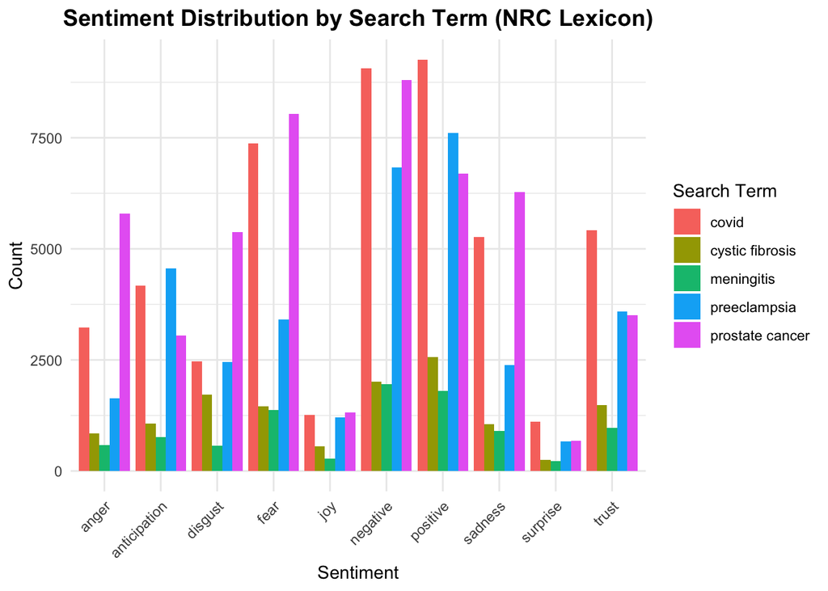

```r
# Visualize sentiment distribution
ggplot(sentiment_counts, aes(x = sentiment, y = n, fill = term)) +
  geom_col(position = "dodge") +
  labs(title = "Sentiment Distribution by Search Term (NRC Lexicon)",
       x = "Sentiment",
       y = "Count",
       fill = "Search Term") +
  theme_minimal() +
  theme(axis.text.x = element_text(angle = 45, hjust = 1),
        plot.title = element_text(hjust = 0.5, size = 14, face = "bold"))
```

Using the NRC lexicon, the most common sentiments including “positive” and “negative” are:

- Covid– positive
- Cystic Fibrosis – positive
- Meningitis – negative
- Preeclampsia – positive
- Prostate Cancer – negative

When “positive” and “negative” are removed:

- Covid – fear
- Cystic Fibrosis – disgust
- Meningitis – fear
- Preeclampsia – anticipation
- Prostate Cancer – fear

When “positive” and “negative” are removed to reveal more specific emotions, a different pattern emerges. “fear” becomes the most dominant sentiment for “covid”, “meningitis”, and “prostate cancer”. For the other terms, “disgust” is the most common for “cystic fibrosis”, and “anticipation” is the highest for “preeclampsia”. This two-step analysis shows that filtering out the general “positive” and “negative” labels uncovers the more specific, and often negative, emotions associated with these medical topics.

### Question 6

```r
afinn <- get_sentiments("afinn")

# Join tokens with AFINN sentiments
afinn_sentiments <- tokens_no_stop %>%
  inner_join(afinn, by = "word")

# Create an index for each abstract
pubmed_indexed <- pubmed %>%
  mutate(abstract_id = row_number())

# Create tokens with abstract IDs
tokens_indexed <- pubmed_indexed %>%
  unnest_tokens(word, abstract) %>%
  anti_join(stop_words, by = "word")

# Join with AFINN and calculate average sentiment per abstract
abstract_sentiment <- tokens_indexed %>%
  inner_join(afinn, by = "word") %>%
  group_by(abstract_id, term) %>%
  summarize(avg_sentiment = mean(value), .groups = "drop")

# Summary statistics by search term
sentiment_summary <- abstract_sentiment %>%
  group_by(term) %>%
  summarize(
    mean_sentiment = mean(avg_sentiment),
    median_sentiment = median(avg_sentiment),
    sd_sentiment = sd(avg_sentiment),
    .groups = "drop"
  )

print("Average sentiment scores by search term:")
```

```
[1] "Average sentiment scores by search term:"
```

```r
print(sentiment_summary)
```

```
# A tibble: 5 × 4
  term            mean_sentiment median_sentiment sd_sentiment
  <chr>                    <dbl>            <dbl>        <dbl>
1 covid                   -0.361           -0.4          1.03
2 cystic fibrosis          0.193            0.333        1.27
3 meningitis              -0.330           -0.5          1.24
4 preeclampsia            -0.263           -0.333        0.961
5 prostate cancer         -0.391           -0.4          0.537
```

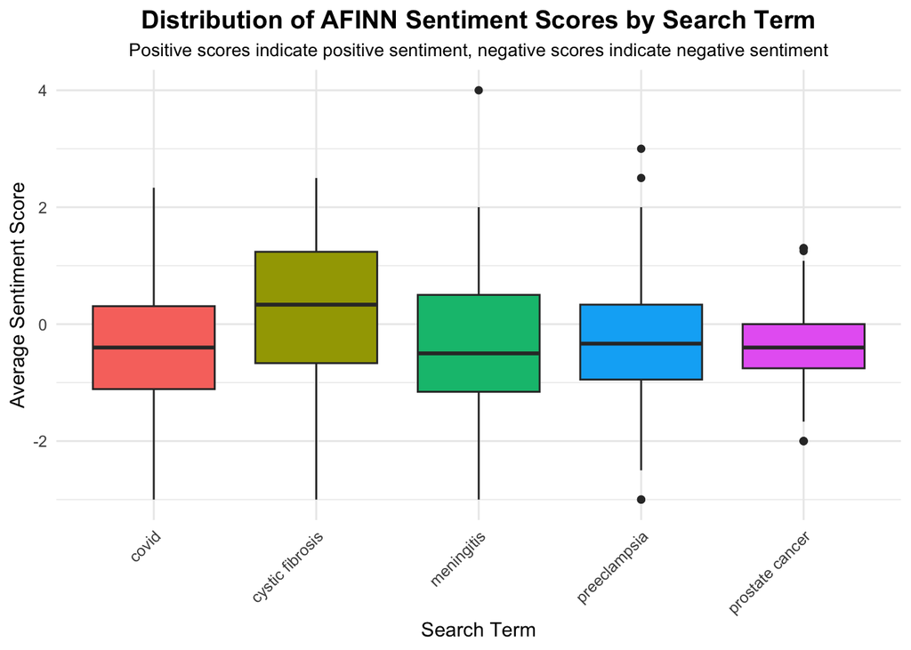

```r
# Visualize sentiment scores by search term
ggplot(abstract_sentiment, aes(x = term, y = avg_sentiment, fill = term)) +
  geom_boxplot(show.legend = FALSE) +
  labs(title = "Distribution of AFINN Sentiment Scores by Search Term",
       x = "Search Term",
       y = "Average Sentiment Score",
       subtitle = "Positive scores indicate positive sentiment, negative scores indicate negative sentiment") +
  theme_minimal() +
  theme(axis.text.x = element_text(angle = 45, hjust = 1),
        plot.title = element_text(hjust = 0.5, size = 14, face = "bold"),
        plot.subtitle = element_text(hjust = 0.5, size = 10))
```

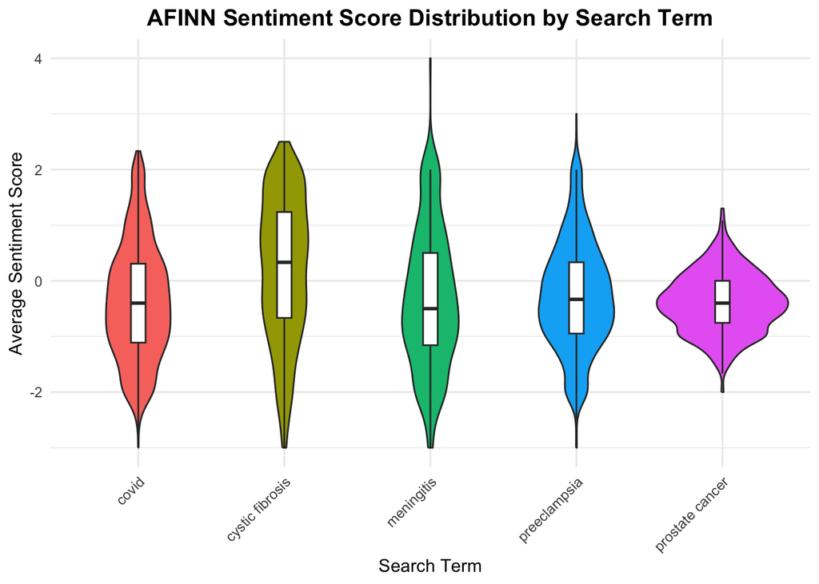

```r
# Alternative visualization: violin plot
ggplot(abstract_sentiment, aes(x = term, y = avg_sentiment, fill = term)) +
  geom_violin(show.legend = FALSE) +
  geom_boxplot(width = 0.1, fill = "white", outlier.shape = NA) +
  labs(title = "AFINN Sentiment Score Distribution by Search Term",
       x = "Search Term",
       y = "Average Sentiment Score") +
  theme_minimal() +
  theme(axis.text.x = element_text(angle = 45, hjust = 1),
        plot.title = element_text(hjust = 0.5, size = 14, face = "bold"))
```